# 22-Model Assumptions

# Linear Model Assumptions

The linear model

$$\begin{equation}
Y_i = \beta_0 + \beta_1 X_i + \varepsilon_i
\end{equation}$$

has several important assumptions for the computation of correct standard errors and any statistic derived from standard errors including a confidence interval and a $p$-value.

1. Normality: the errors $\varepsilon$ have mean zero and a normal distribution. Often this is mistakenly interpreted as the response $Y$ has to be normally distributed and sometimes that even $X$ has to be normally distributed. But the assumption applies only to the residuals of the fit model.
2. Independence: the errors are independent of each other
3. Homoskedasticity: the variance of the errors is homogenous
4. the errors are identically distributed
5. the error is independent of any $X$
6. the error is independent of the response

Here I model fake data in which $X$ is niformly distributed. $Y$ is a linear function of $X$ + normally distributed error, so the $Y$ is also uniformly distributed but the error is normal. The histogram of $Y$ shows this uniform distribution clearly. The histogram of the residuals from the fit model show the normal distribution of the error clearly. d

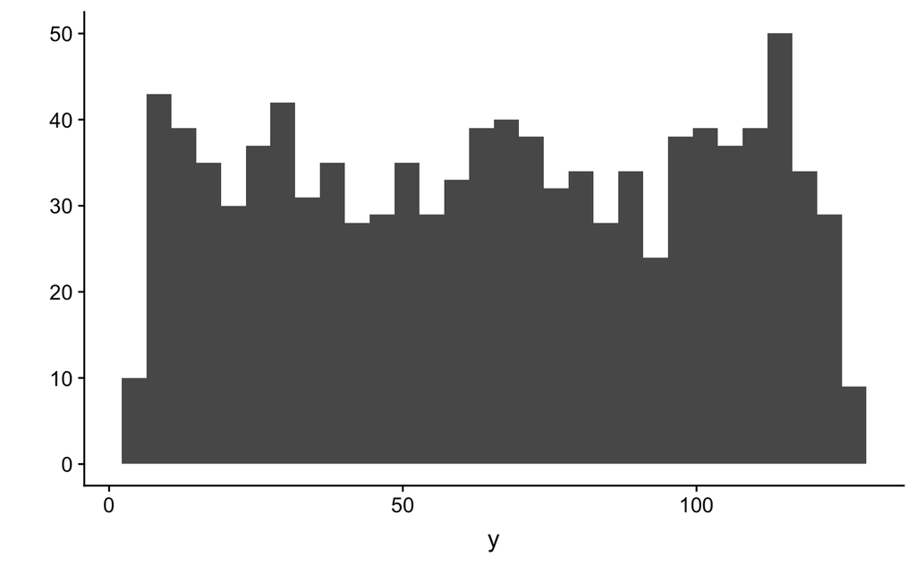

```r
n <- 1000
x <- runif(n)*100
sigma <- 1.0
y <- 5 + 1.2*x + rnorm(n, sd=sigma)
qplot(y)
```

```r
fit <- lm(y ~ x)
summary(fit)
```

```
Call:
lm(formula = y ~ x)

Residuals:
     Min       1Q   Median       3Q      Max
-3.15323 -0.66997  0.00643  0.69700  2.99783

Coefficients:
            Estimate Std. Error t value Pr(>|t|)
(Intercept) 5.145340   0.063898   80.53   <2e-16 ***
x           1.197493   0.001092 1096.19   <2e-16 ***
---
Signif. codes:  0 ‘***’ 0.001 ‘**’ 0.01 ‘*’ 0.05 ‘.’ 0.1 ‘ ’ 1

Residual standard error: 1.025 on 998 degrees of freedom
Multiple R-squared:  0.9992,    Adjusted R-squared:  0.9992
F-statistic: 1.202e+06 on 1 and 998 DF,  p-value: < 2.2e-16
```

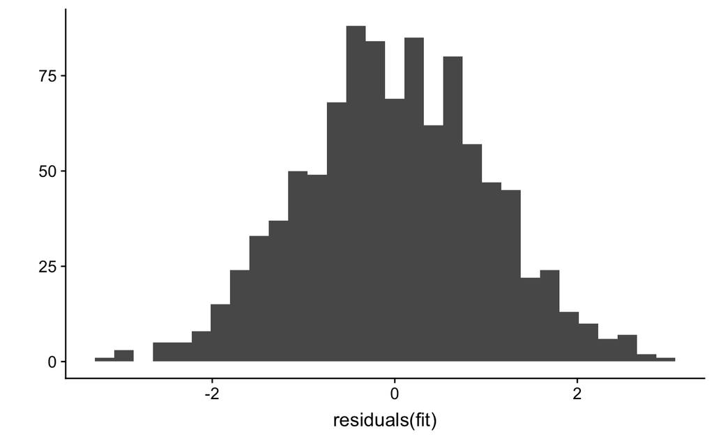

```r
qplot(residuals(fit))
```

There are tests for normality but I do not recommend these because the test doesn’t add any value from what one can gain by simply inspecting the residuals.

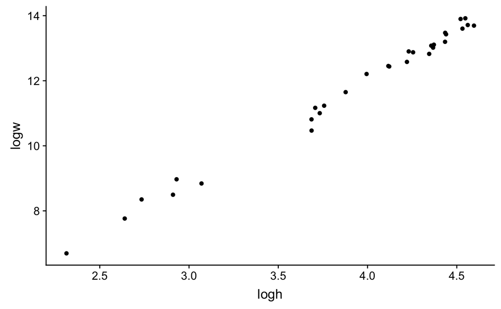

```r
n <- 30
h <- runif(n)*90 + 10
w <- h^3
sigma <- rnorm(n)*.2
logh <- log(h)
logw <- log(w) + sigma
qplot(logh, logw)
```

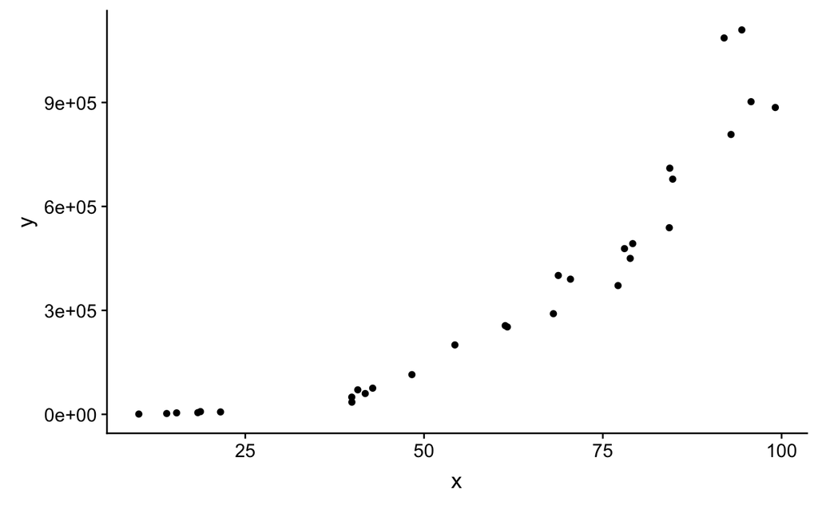

```r
x <- h
y <- exp(logw)
qplot(x=x, y=y)
```

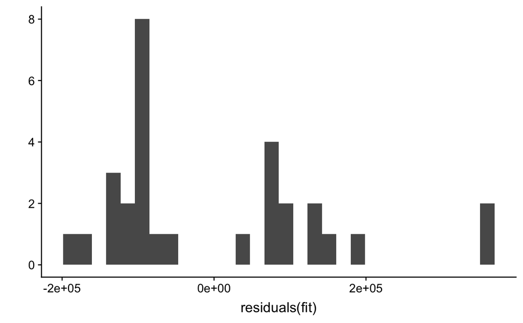

```r
fit <- lm(y ~ x)
qplot(residuals(fit))
```

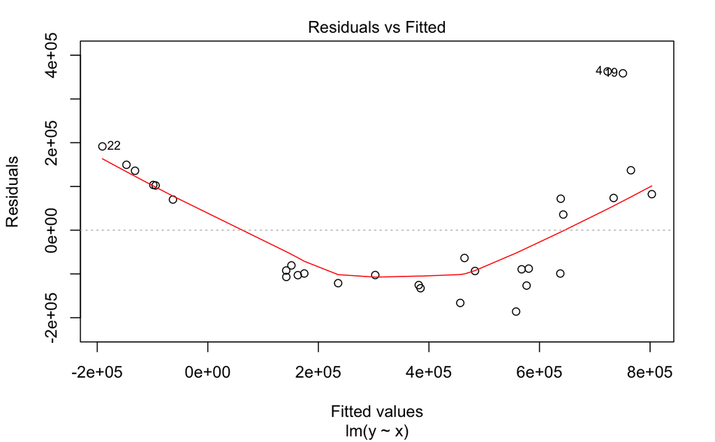

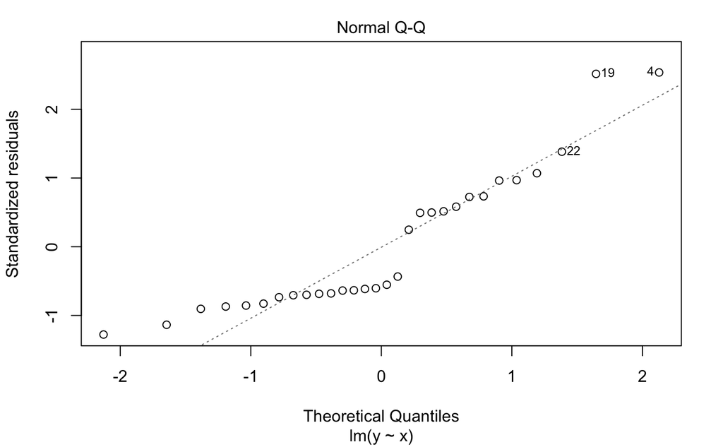

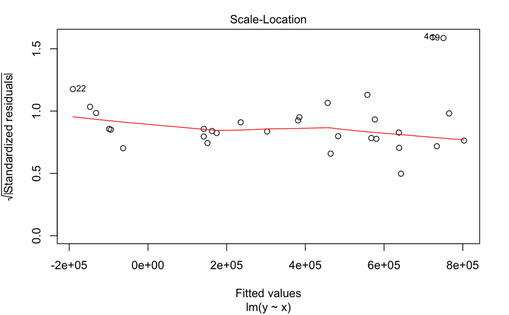

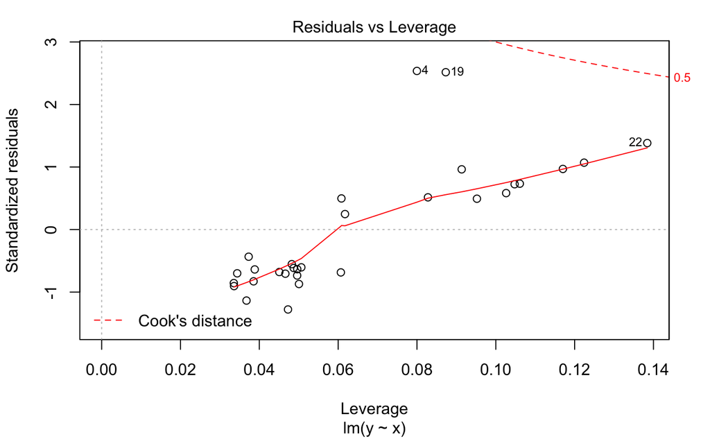

```r
plot(fit)
```